# Precio del aguacate hass de exportación en los últimos 6 años

# Precio del aguacate de exportación

ya que esta grafica tomada de (https://www.bbc.com/mundo/noticias-49209380) va dirigida un publico en general, la manera en la que esta presentada no es la mas idonea para la compreción de dicho publico, para todos estos no es facil comprender el precio correcto(expecifico), la forma en la que se preseta la reacion de varible debería estar a la inversa, ademas de que debería dar un dato preciso del valor en cada año, tambien no presenta un nombre para cada variable, se le debería incluir un denileancion sobre cada barra, para darle una mejor interpretación.

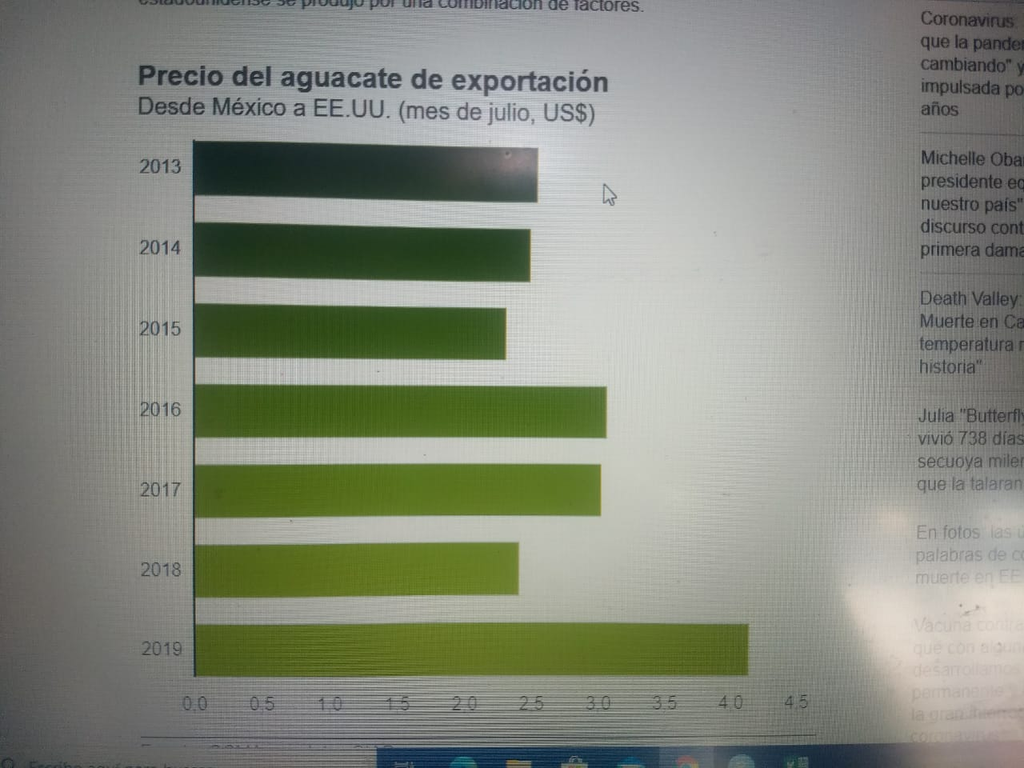

# Propuestas Para Nueva Grafica

**1.** Añidir un delineo a la grafica.

**2.** Nombre a las variables.

**3.** Invertir la forma en la que esta presentada.

**4.** Ponerle el dato especifico encima de cada barra.

[figure not shown]